# 第7讲｜决策树与集成学习

## 19. 提升树估计需求概率

先看初始化：训练集高需求比例$\pi$是初始概率，不是odds。先算几率，再取自然对数，得到作为初始分数的对数几率（log-odds / logit）：

$$\mathrm{odds}=\frac{\pi}{1-\pi},\qquad F_0=\ln(\mathrm{odds}).$$

本例$\pi=234/491\approx0.4766$，$\mathrm{odds}=234/257\approx0.9105$，$F_0\approx-0.0938$。

分类流程：由分数计算概率p，初始时$p_0=\sigma(F_0)=\pi$，以$y_i-p_i$作为下一棵回归树的学习目标。第$m$棵回归树对当前样本给出的分数修正记作$h_m(x)$，取自该样本所在叶子的最终输出。实际加入已有分数的是$\eta h_m(x)$，随后重新计算概率。训练完成后，按概率阈值输出类别。

分数可以小于0或大于1，概率始终在0到1之间。新树输出的是分数修正，不是新概率。拟合修正目标后，sklearn还会按损失优化叶值，最终树输出不一定等于$y_i-p_i$。

沿用分类机制实验：前491天、temp与hum两个输入、50轮深度1树、学习率0.1、种子42。选取训练段中第一条高需求记录（2011-04-21）逐轮观察，不按模型表现挑样本。其真实cnt=4189、y=1；阈值t=0.5仅用于本例。

记$h_m$为第$m$棵回归树，$h_m(x)$为它对输入$x$的输出。更新规则为：

$$F_m(x)=F_{m-1}(x)+\eta h_m(x),\qquad p_m(x)=\sigma(F_m(x)).$$

表中$h_m(x)$列表示该轮单棵树对同一记录的输出；$F_m(x)$是前$m$轮累计分数。初始轮尚无树，用`/`表示。表格只摘第0、1、5、20轮，不能把相邻展示行的分数差当成单轮修正。

```python
# 按课件配置拟合分类GBDT，下一格跟踪同一条记录。
demand_boost = GradientBoostingClassifier(n_estimators=50, learning_rate=.1,
    max_depth=1, loss="log_loss", random_state=42)
demand_boost.fit(X_demand, demand_y)
```

```
GradientBoostingClassifier(max_depth=1, n_estimators=50, random_state=42)
```

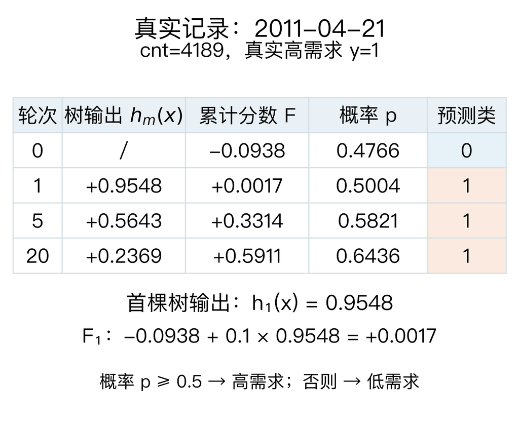

```python
# 取训练段第一条高需求记录，避免按预测效果挑选样本。
flow_row = int(np.flatnonzero(demand_y == 1)[0])
flow_x = X_demand.iloc[[flow_row]]
prior = float(demand_y.mean())
prior_odds = prior / (1-prior)  # odds比较高需求与非高需求的概率。
initial_score = float(np.log(prior_odds))
flow_threshold = .5
flow_rows = [{"round":0,"score":initial_score,"probability":prior,"predicted_class":int(prior >= flow_threshold),"tree_update":None}]
for m, score in enumerate(demand_boost.staged_decision_function(flow_x), start=1):
    if m in (1,5,20):
        score = float(np.asarray(score).ravel()[0]); probability = float(1/(1+np.exp(-score)))
        flow_rows.append({"round":m,"score":score,"probability":probability,"predicted_class":int(probability >= flow_threshold),
            "tree_update":float(demand_boost.estimators_[m-1,0].predict(flow_x.to_numpy())[0])})
first_tree_update = float(demand_boost.estimators_[0,0].predict(flow_x.to_numpy())[0])
# sklearn分类树的叶值已按损失优化；核对加到分数上，而非加到概率上。
assert np.isclose(flow_rows[1]["score"], initial_score + demand_boost.learning_rate*first_tree_update)
flow_sample = {"date":fit_frame.iloc[flow_row].dteday.strftime("%Y-%m-%d"),"cnt":int(y_fit[flow_row]),"y":int(demand_y[flow_row]),"threshold":flow_threshold}
plots.classification_score_flow(flow_rows, flow_sample, demand_boost.learning_rate, first_tree_update, ASSETS/"l7-classification-score-flow.svg")
display(Image(filename=str(ASSETS/"l7-classification-score-flow.png")))
_ = (ASSETS/"l7-classification-score-flow.json").write_text(json.dumps({"sample":flow_sample,"rows":flow_rows,"learning_rate":demand_boost.learning_rate,"first_tree_update":first_tree_update,"features":demand_features,"fit_rows":491,"max_depth":1,"n_estimators":50,"seed":42},ensure_ascii=False,indent=2))
```

### 为什么用$y_i-p_i$修正？它与负梯度有什么关系？

以上一页同一条高需求记录的初始状态为例，$y_i=1$、$p_i\approx0.4766$，修正目标$y_i-p_i\approx0.5234$，方向是增大累计分数。

前面拟合残差，其实是在拟合损失对当前累计输出的**负梯度（negative gradient）**：

$$\ell_i=\frac12(y_i-F_i)^2,\qquad-\frac{\partial\ell_i}{\partial F_i}=y_i-F_i.$$

这里$F_i=F(x_i)$是当前输出，$y_i$是真实值。负梯度描述应怎样调整输出使损失局部下降；一半系数只为简化求导，不改变损失最小点。

分类采用二元交叉熵，$F_i$变为连续分数，$p_i=\sigma(F_i)$。完整的单样本损失是：

$$\ell_i=-y_i\ln p_i-(1-y_i)\ln(1-p_i).$$

对分数求导得到$\partial\ell_i/\partial F_i=p_i-y_i$，所以新树的学习目标是$y_i-p_i$。它是连续数值，分类提升也使用回归树。非平方损失下，拟合分区后叶值还可能进一步优化，不能直接把最终输出都等同叶内负梯度均值。

以上用同一条高需求记录解释分数更新。[sklearn解释](https://scikit-learn.org/stable/modules/ensemble.html#mathematical-formulation)。

### 扩展阅读：常见损失、学习目标与叶子修正值

固定叶子$R$，无样本权重，$x\in R$。记$F_i=F_{m-1}(x_i)$，回归残差$e_i=y_i-F_i$，分类概率$p_i=\sigma(F_i)$，$r_i=-\partial\ell_i/\partial F_i$。叶值为$h_m(x)$，实际累加$\eta h_m(x)$。

| 损失 | 单样本损失 | 负梯度学习目标 | 叶子输出 |
| --- | --- | --- | --- |
| 平方损失 `loss="squared_error"` | $\ell_i=\frac{1}{2}e_i^2$ | $r_i=e_i$ | $h_m(x)=\frac{1}{n_R}\sum_{i\in R}e_i$；叶内残差的均值（精确最优） |
| 二分类对数损失 `loss="log_loss"` | $\ell_i=-y_i\ln p_i-(1-y_i)\ln(1-p_i)$ | $r_i=y_i-p_i$ | $h_m(x)=\frac{\sum_{i\in R}(y_i-p_i)}{\sum_{i\in R}p_i(1-p_i)}$；一步牛顿更新（近似更新） |
| 绝对损失 `loss="absolute_error"` | $\ell_i=\lvert e_i\rvert$ | $r_i=\mathrm{sign}(e_i)$ | $h_m(x)=\mathrm{median}_{i\in R}(e_i)$；叶内残差的中位数（精确最优） |
| Huber损失 `loss="huber"` | $\ell_i=\frac{1}{2}\min(e_i^2,\delta^2)+\delta\max(\lvert e_i\rvert-\delta,0)$ | $r_i=\mathrm{clip}_{\delta}(e_i)$ | $h_m(x)=a_R+\frac{1}{n_R}\sum_{i\in R}\mathrm{clip}_{\delta}(e_i-a_R)$；从中位残差出发再修正（近似更新） |
| 分位数损失 `loss="quantile"` | $\ell_i=e_i\left(\tau-\mathbf{1}_{\{e_i<0\}}\right)$ | $r_i=\tau-\mathbf{1}_{\{e_i<0\}}$ | $h_m(x)=Q_{\tau}\left(\{e_i:i\in R\}\right)$；叶内残差的τ分位数（按库的百分位约定计算） |

其中$n_R$为叶内样本数，$a_R=\operatorname{median}_{i\in R}(e_i)$。$\operatorname{clip}_\delta(u)=\max(-\delta,\min(u,\delta))$。$Q_\tau$为$\tau$分位数，指示函数在条件成立时为1。平方损失取一半方便求导，报告的MSE仍为平方误差均值。绝对/分位数损失在零残差处采用合法次梯度，sklearn的边界约定可不同。

二分类对数损失用于分类，其余四种用于回归。Huber与对数损失列的是sklearn 1.9.0的近似叶值更新。quantile的$\tau$对应`alpha`，Huber的`alpha`用于确定本轮截断阈值$\delta$。

- 平方损失：[ESL：表10.2、算法10.3](https://course.ccs.neu.edu/ds4420sp20/readings/ESLII.pdf#page=380)
- 绝对损失：[Friedman：LAD TreeBoost](https://www.cse.cuhk.edu.hk/irwin.king/_media/presentations/2001_greedy_function_approximation_a_gradient_boosting_machine.pdf)
- Huber损失：[Friedman：Huber M-TreeBoost](https://www.cse.cuhk.edu.hk/irwin.king/_media/presentations/2001_greedy_function_approximation_a_gradient_boosting_machine.pdf)
- 分位数损失：[Koenker & Bassett：Regression Quantiles](https://people.eecs.berkeley.edu/~jordan/sail/readings/koenker-bassett.pdf)
- 二分类对数损失：[ESL：算法10.3及下方推导](https://course.ccs.neu.edu/ds4420sp20/readings/ESLII.pdf#page=380)

[sklearn损失说明](https://scikit-learn.org/stable/modules/ensemble.html#gradient-boosting-loss) · [损失实现](https://github.com/scikit-learn/scikit-learn/blob/1.9.0/sklearn/_loss/loss.py) · [叶值更新](https://github.com/scikit-learn/scikit-learn/blob/1.9.0/sklearn/ensemble/_gb.py)

**展开推导：从学习目标到叶子输出**

### 从学习目标到叶子输出

$y_i-p_i$是每条样本的学习目标，$h_m(x)$是训练好的树对输入$x$的输出。固定叶子$R$，所有落入该叶的输入共享修正$c=h_m(x)$。

平方误差回归中，$F_i$为当前预测：

$$L_R(c)=\frac12\sum_{i\in R}(y_i-F_i-c)^2,\quad L_R'(c)=\sum_{i\in R}(F_i+c-y_i).$$

令导数为0，得到$c^*=|R|^{-1}\sum_{i\in R}(y_i-F_i)$，即平均残差。

二分类中，$F_i$是当前logit分数，$p_i=\sigma(F_i)$。加入修正$c$后的对数损失为：

$$L_R(c)=\sum_{i\in R}\left[\ln(1+e^{F_i+c})-y_i(F_i+c)\right].$$

$$L_R'(0)=\sum_{i\in R}(p_i-y_i),\qquad L_R''(0)=\sum_{i\in R}p_i(1-p_i).$$

本例sklearn在分组后做一步牛顿更新（无样本权重）：

$$h_m(x)=-\frac{L_R'(0)}{L_R''(0)}=\frac{\sum_{i\in R}(y_i-p_i)}{\sum_{i\in R}p_i(1-p_i)},\qquad x\in R.$$

这是局部近似修正，不是对数损失叶值的精确最优解。分母用曲率调整修正幅度；实际加入累计分数的是$\eta h_m(x)$。

上一页表格的首轮所在叶子298条记录，其中213条高需求，$p_0=234/491$。单样本目标$1-p_0\approx0.5234$，叶内平均目标$213/298-p_0\approx0.2382$；最终叶值：

$$h_1(x)=\frac{213-298p_0}{298p_0(1-p_0)}\approx0.9548.$$

后续各样本当前概率可能不同，不能只用叶内正类比例替代。参考[sklearn数学说明](https://scikit-learn.org/stable/modules/ensemble.html#mathematical-formulation)。

### 扩展阅读：AdaBoost的训练步骤

AdaBoost逐轮训练并组合基分类器。以下采用经典二分类记号$y_i,h_m(x_i)\in\{-1,+1\}$。

1. 初始化：n条训练记录各取权重$w_i=1/n$。
2. 用当前样本权重训练基分类器$h_m$。
3. 计算加权错分率$\epsilon_m=\sum_iw_i\mathbf{1}[h_m(x_i)\ne y_i]$，再计算$\alpha_m=\frac{1}{2}\ln\frac{1-\epsilon_m}{\epsilon_m}$。
4. 分错记录的权重乘$e^{\alpha_m}$，分对记录的权重乘$e^{-\alpha_m}$，再归一化，使权重之和为1。重复第2至4步。
5. 最终按$\hat y(x)=\operatorname{sign}(\sum_m\alpha_mh_m(x))$加权投票。

样本权重决定训练时关注谁，组合权重$\alpha_m$决定各分类器投票贡献。分类树、Logistic回归、高斯朴素贝叶斯等可作为支持带权训练的基分类器。若基学习器不支持带权训练，也可按当前权重有放回重抽样后训练，称为boosting by resampling；有限抽样不保证与直接加权得到同一模型。见[Experiments with a New Boosting Algorithm（ICML 1996）](https://www.schapire.net/papers/FreundSc96.pdf#page=4)。

上式适用$0<\epsilon_m<0.5$，零错分时提前结束，不优于随机的分类器不继续采用。

[sklearn说明与API](https://scikit-learn.org/stable/modules/ensemble.html#adaboost)。sklearn SAMME与上面的经典二分类系数表达有整体因子2的差异，归一调权及最终分类投票等价。

原理与指数损失推导供自主阅读：[ESL §10.4–10.5](https://course.ccs.neu.edu/ds4420sp20/readings/ESLII.pdf#page=362) · [Understanding Machine Learning §10.2](https://www.cs.huji.ac.il/~shais/UnderstandingMachineLearning/understanding-machine-learning-theory-algorithms.pdf#page=135)。执行上述算法不需要另外调用整体loss函数。

### 扩展实验：两特征线性分类器怎样做AdaBoost？

沿用UCI单车数据，从前491条训练记录中按固定种子21抽60条，输入气温`temp`和湿度`hum`，标签为`cnt >= 4000`。这组样本用于课堂展示调权与组合过程，不评价泛化。

每个基分类器是一条二维直线。预设每15°一个方向，在各方向上检查相邻投影值中点，并比较两侧类别方向，按当前加权错分率选线。这是真实拟合，不是手画边界，也不是Logistic回归。

```python
from sklearn.preprocessing import StandardScaler
ada_frame = fit_frame.sample(n=60, random_state=21).sort_index()
ada_raw = ada_frame[["temp", "hum"]].to_numpy()
ada_y = np.where(ada_frame["cnt"].to_numpy() >= 4000, 1, -1)
ada_scaler = StandardScaler().fit(ada_raw)
ada_X = ada_scaler.transform(ada_raw)
# 缩放器仅拟合这60条训练记录；±1标签用于AdaBoost计算。
print("训练记录:", len(ada_y), "高需求:", int((ada_y == 1).sum()))
```

```
训练记录: 60 高需求: 32
```

```python
# 比较各方向上的候选直线；每轮将按当前权重重新选择。
ada_candidates, ada_predictions = [], []
for angle in np.arange(0, 180, 15):
    direction = np.array([np.cos(np.deg2rad(angle)), np.sin(np.deg2rad(angle))])
    projection = ada_X @ direction
    values = np.unique(projection)
    cuts = np.r_[values[0]-1, (values[:-1]+values[1:])/2, values[-1]+1]
    for cut in cuts:
        for polarity in [1, -1]:
            ada_candidates.append((direction.copy(), float(cut), polarity))
            ada_predictions.append(np.where(polarity*(projection-cut) >= 0, 1, -1))
ada_predictions = np.asarray(ada_predictions)
print("候选直线分类器:", len(ada_candidates))
```

```
候选直线分类器: 1458
```

```python
ada_weights = np.full(len(ada_y), 1/len(ada_y))
ada_score = np.zeros(len(ada_y))
ada_rounds = []
for m in range(3):
    # 同一批真实标签不变，当前样本权重决定选择哪条直线。
    errors = (ada_predictions != ada_y) @ ada_weights
    selected = int(np.argmin(errors))
    error = float(errors[selected])
    assert 0 < error < .5  # 本例每轮均需优于随机猜测，且未达到零错分。
    alpha = .5*np.log((1-error)/error)
    prediction = ada_predictions[selected]
    ada_score += alpha*prediction
    ada_rounds.append({"round": m+1, "selected": selected, "weights": ada_weights.copy(),
                       "error": error, "alpha": float(alpha), "ensemble_score": ada_score.copy()})
    ada_weights *= np.exp(-alpha*ada_y*prediction)
    ada_weights /= ada_weights.sum()
print("三轮加权错分率:", [round(r["error"], 3) for r in ada_rounds])
```

```
三轮加权错分率: [0.083, 0.1, 0.152]
```

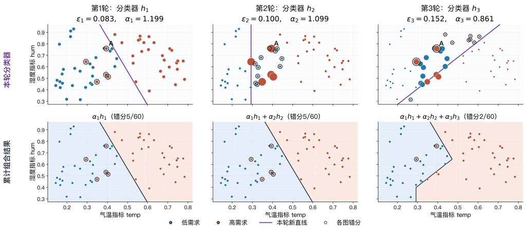

|  | round | weighted_error | alpha | train_mistakes | exponential_loss |
| --- | --- | --- | --- | --- | --- |
| 0 | 1 | 0.083333 | 1.198948 | 5 | 0.552771 |
| 1 | 2 | 0.100000 | 1.098612 | 5 | 0.331662 |
| 2 | 3 | 0.151515 | 0.861383 | 2 | 0.237835 |

```python
import l7_adaboost_linear_plots as ada_plots
ada_plots.plot_rounds(ada_raw, ada_y, ada_scaler, ada_candidates, ada_rounds,
                     ASSETS/"l7-adaboost-linear.svg")
display(Image(filename=str(ASSETS/"l7-adaboost-linear.png")))
ada_summary = [{"round": r["round"], "weighted_error": r["error"], "alpha": r["alpha"],
                "train_mistakes": int((np.where(r["ensemble_score"] >= 0, 1, -1) != ada_y).sum()),
                "exponential_loss": float(np.exp(-ada_y*r["ensemble_score"]).mean())} for r in ada_rounds]
display(pd.DataFrame(ada_summary))
_ = (ASSETS/"l7-adaboost-linear.json").write_text(json.dumps({"seed": 21, "n_samples": 60,
 "features": ["temp", "hum"], "sample_indices": ada_frame.index.tolist(), "rounds": ada_summary},
 ensure_ascii=False, indent=2))
```

**读图**：三列依次是第1、2、3轮，横轴为气温、纵轴为湿度，点颜色表示真实类别。上排显示本轮新分类直线，圆面积表示本轮训练前的样本权重，黑圈为本轮错分。下排显示截至本轮加权投票得到的分类区域，点大小固定，黑圈为组合后的错分。

A始终是同一条记录，第1轮分错、第2轮新分类器分对。第2轮新直线已改变，但其组合权重小于首轮，累计分类暂未改变。第3轮组合后边界形成折线，累计错分数从5降到2。

这里的60条训练记录按seed21抽取，用于教学展示。累计训练错分为5、5、2，并不保证每轮准确率上升，也不是泛化成绩。样本权重决定训练关注谁，组合权重决定各分类器投票贡献。

参考[ESL第10章](https://course.ccs.neu.edu/ds4420sp20/readings/ESLII.pdf#page=358)。

### 扩展阅读：梯度提升树的常用实现

同样是逐轮加树，默认的生长方式、特征处理和硬件实现会改变调参工作量。下面从使用时需要做的选择来比较。

| 框架 | 机制与默认行为 | 适用场景与主要权衡 |
| --- | --- | --- |
| [XGBoost](https://github.com/dmlc/xgboost) ★ 28,956 [v3.4.2 · 2026-09-15](https://github.com/dmlc/xgboost/releases/tag/v3.4.2) | 默认优先分裂靠近根部的节点，使用直方图统计。二阶信息与正则化共同参与建树。 | 通用表格任务的强基线。接口与部署选择丰富，仍需验证模型复杂度。 |
| [CatBoost](https://github.com/catboost/catboost) ★ 9,195 [v1.2.10 · 2026-02-19](https://github.com/catboost/catboost/releases/tag/v1.2.10) | 内置类别特征统计与组合，减少手工编码。默认使用CPU。 | 类别字段多时值得优先比较。编码更省事，类别统计计算也有开销。 |
| LightGBM ★ 18,954 [v4.7.0 · 2026-07-18](https://github.com/lightgbm-org/LightGBM/releases/tag/v4.7.0) | 直方图统计＋按叶生长（leaf-wise），优先分裂损失下降最大的叶子。 | 数据量大、时间或内存受限。提高效率的同时，要约束局部过细的切分。 |
| [ThunderGBM](https://github.com/Xtra-Computing/thundergbm) ★ 716 [0.3.2 · 2019-05-07](https://github.com/Xtra-Computing/thundergbm/releases/tag/0.3.2) | GPU并行的GBDT与随机森林，关注大规模和稀疏数据的计算效率。 | 适合了解GPU并行树训练，或在特定硬件上比较训练效率。 |

**选择建议**：通常先试XGBoost。类别字段多、想减少编码工作时试CatBoost。数据量大、训练慢或内存紧张时试LightGBM。ThunderGBM可作为GPU并行树训练的扩展阅读。

**GPU加速**：四者均支持GPU训练。需要加速时，先查看已选框架的GPU版本，并确认它支持现有硬件。 [XGBoost](https://xgboost.readthedocs.io/en/stable/gpu/index.html) · [CatBoost](https://catboost.ai/docs/en/features/training-on-gpu) · [LightGBM](https://lightgbm.readthedocs.io/en/stable/Installation-Guide.html#build-gpu-version) · [ThunderGBM](https://rocm.docs.amd.com/projects/thundergbm/en/docs-26.01/)

**扩展阅读**：FedTree是面向联邦学习场景的梯度提升树训练框架。[论文（MLSys 2023）](https://proceedings.mlsys.org/paper_files/paper/2023/file/3430e7055936cb8e26451ed49fce84a6-Paper-mlsys2023.pdf)

### 集成学习：Bagging、Boosting与Stacking

集成学习（Ensemble Learning）将多个基模型（base model）的预测组合起来，争取更好的泛化表现。基模型也称基学习器（base learner），可以使用相同或不同的方法。

| 维度 | Bagging 自助聚合／装袋法 | Boosting 提升法 | Stacking 堆叠泛化 |
| --- | --- | --- | --- |
| 训练方式 | 各基模型分别拟合，可并行 | 后一个模型依赖当前组合，通常串行 | 先训练多个基模型，再训练组合它们的元模型 |
| 数据与目标 | Bootstrap重抽样，形成不同训练集 | AdaBoost调样本权重，GBDT学负梯度 | 用基模型的折外预测作新特征，训练元模型 |
| 预测组合 | 回归平均，分类投票或平均概率 | 加权组合，或逐轮累加修正 | 由元模型学习组合规则 |
| 主要作用与优势 | 降低预测波动，流程简单，可作OOB评价 | 逐轮修正拟合不足，可选择不同损失 | 利用不同模型的互补信息，灵活学习如何组合 |
| 典型方法 | Bagging树、随机森林 | AdaBoost、GBDT | 线性回归、随机森林、GBDT预测后，再用回归器组合 |
| 局限与开销 | 改善共同偏差有限，树数增加存储与预测成本 | 轮数、学习率及树复杂度需验证，可能拟合噪声 | 增加拟合与预测开销，元模型可能过拟合，需防预测泄漏 |

**Stacking的折外预测**：预测某条训练记录时，该基模型没有用这条记录拟合。用这些预测训练元模型，避免直接使用基模型在自身训练集上的预测。这里仅作机制介绍。

[sklearn：Stacked generalization](https://scikit-learn.org/stable/modules/ensemble.html#stacked-generalization)

### 神经网络中的集成：深度集成（Deep Ensemble）

独立训练多个神经网络，以不同初始化等产生差异，再平均分类概率或回归预测。不要求Bootstrap，也不逐轮修正前一个模型。 [Simple and Scalable Predictive Uncertainty Estimation using Deep Ensembles（NeurIPS 2017）](https://proceedings.neurips.cc/paper/2017/hash/9ef2ed4b7fd2c810847ffa5fa85bce38-Abstract.html)

### 集成学习：Bagging、Boosting与Stacking

[figure not shown]

共享单车上的Bagging、Boosting与Stacking

Bagging将800、1000、900次预测取平均，得到900次。平方误差Boosting从600次开始，加上已乘学习率的200和100次修正。Stacking用历史折外预测及真实次数训练元模型，再学习如何组合各模型的预测。

## 20. 森林叶子下限：作业对照

固定随机森林其余设置，仅比较 `min_samples_leaf=1` 与 `5`。使用前 611 天内部相同三折时序验证，表格保留逐折和平均 MSE、MAE。

```python
leaf_check = {}
for leaf_min in (1,5):
    leaf_check[leaf_min] = []
    for fold,(tr,va) in enumerate(tscv.split(development),start=1):
        model = RandomForestRegressor(n_estimators=50,max_features=.7,min_samples_leaf=leaf_min,min_samples_split=20,random_state=42,n_jobs=1)
        model.fit(development.iloc[tr][forest_features],development.iloc[tr]["cnt"])
        Xtr = development.iloc[tr][forest_features]; Xva = development.iloc[va][forest_features]
        train_actual = development.iloc[tr]["cnt"]; actual = development.iloc[va]["cnt"]
        train_pred = model.predict(Xtr); pred = model.predict(Xva)
        leaf_check[leaf_min].append({"fold":fold,"train_mse":float(mean_squared_error(train_actual,train_pred)),"mse":float(mean_squared_error(actual,pred)),"mae":float(mean_absolute_error(actual,pred))})
leaf_table = pd.DataFrame([{"min_samples_leaf":leaf,"fold":r["fold"],"训练MSE":r["train_mse"],"验证MSE":r["mse"],"验证MAE":r["mae"]} for leaf,rows in leaf_check.items() for r in rows])
display(leaf_table.round(1)); display(leaf_table.groupby("min_samples_leaf")[["训练MSE","验证MSE","验证MAE"]].mean().round(1))
```

|  | min_samples_leaf | fold | 训练MSE | 验证MSE | 验证MAE |
| --- | --- | --- | --- | --- | --- |
| 0 | 1 | 1 | 150737.1 | 661377.3 | 592.3 |
| 1 | 1 | 2 | 185188.5 | 3232082.3 | 1473.2 |
| 2 | 1 | 3 | 218206.3 | 1412550.2 | 1021.3 |
| 3 | 5 | 1 | 173670.7 | 666822.5 | 607.3 |
| 4 | 5 | 2 | 213880.8 | 3234442.6 | 1472.3 |
| 5 | 5 | 3 | 268514.9 | 1621533.0 | 1112.9 |

| min_samples_leaf | 训练MSE | 验证MSE | 验证MAE |
| --- | --- | --- | --- |
| 1 | 184710.6 | 1768669.9 | 1028.9 |
| 5 | 218688.8 | 1840932.7 | 1064.2 |

## 附录｜导出课件复算数据

以下只整理前面已计算的模型与结果，写入本章assets，供课件与数值核对使用。无需逐行阅读。

```python
# 汇总可复算数据：完整序列与逐折数值保存在 JSON，输出格只显示摘要
complexity_summary={}
for d in depths:
    tr_scores=[]; va_scores=[]
    for tr,va in tscv.split(development):
        mm=DecisionTreeRegressor(max_depth=d,random_state=42).fit(development.iloc[tr][["temp"]],development.iloc[tr]["cnt"])
        tr_scores.append(float(mean_squared_error(development.iloc[tr]["cnt"],mm.predict(development.iloc[tr][["temp"]]))))
        va_scores.append(float(mean_squared_error(development.iloc[va]["cnt"],mm.predict(development.iloc[va][["temp"]]))))
    complexity_summary[str(d)]={"train_mse_per_fold":tr_scores,"valid_mse_per_fold":va_scores,"train_mean":float(np.mean(tr_scores)),"train_std":float(np.std(tr_scores)),"valid_mean":float(np.mean(va_scores)),"valid_std":float(np.std(va_scores))}
result={"generated_on":"2026-11-09","data":{"source":"lessons/06-model-selection/notebook/data/bike-sharing/day.csv","target":"cnt (daily rental count)","rows_total":len(bike_all),"development_indices":development.index.tolist(),"fit_indices":fit_frame.index.tolist(),"dev_validation_indices":dev_valid.index.tolist(),"legacy_holdout_indices":legacy_holdout.index.tolist(),"development_dates":development.dteday.dt.strftime("%Y-%m-%d").tolist(),"fit_dates":fit_frame.dteday.dt.strftime("%Y-%m-%d").tolist(),"dev_validation_dates":dev_valid.dteday.dt.strftime("%Y-%m-%d").tolist(),"legacy_holdout_dates":legacy_holdout.dteday.dt.strftime("%Y-%m-%d").tolist(),"fit_cnt":y_fit.tolist(),"fit_temp":x_fit.tolist(),"dev_validation_cnt":dev_valid.cnt.tolist(),"dev_validation_temp":dev_valid.temp.tolist()},
 "tree_models":{"max_leaf_nodes_2":{"params":{"max_leaf_nodes":2,"random_state":42},"nodes":node_rows(tree2,["temp"])},"max_leaf_nodes_3":{"params":{"max_leaf_nodes":3,"random_state":42},"nodes":node_rows(tree3,["temp"]),"root_threshold_matches_two_leaf_tree":bool(tree2.tree_.threshold[0]==tree3.tree_.threshold[0])}},
 "selected_leaf":{"sample_index":int(fit_frame.index[sample_row]),"sample_date":sample_date,"sample_temp":float(x_fit[sample_row]),"leaf_node":chosen_leaf,"record_indices":fit_frame.index[chosen_mask].tolist(),"record_dates":fit_frame.loc[chosen_mask,"dteday"].dt.strftime("%Y-%m-%d").tolist(),"record_temp":x_fit[chosen_mask].tolist(),"record_cnt":y_fit[chosen_mask].tolist(),"mean_cnt":chosen_mean,"purpose":"fixed mechanism walk-through only; not used for scoring or model selection"},
 "root_split_enumeration":{"candidate_midpoints":candidate_cuts.tolist(),"sse":sse_values.tolist(),"best_threshold":best_threshold,"best_sse":float(sse_values[best_i]),"tree_root_threshold":cut1},
 "complexity_cv":{"splitter":"TimeSeriesSplit(n_splits=3)","depths":depths,"results":complexity_summary},
 "bootstrap":{"params":{"n_resamples":30,"sampling":"row-wise IID bootstrap","max_leaf_nodes":3,"random_state":42},"grid":xgrid[:,0].tolist(),"predictions":bootstrap_curves.tolist(),"mean_prediction":bootstrap_curves.mean(axis=0).tolist()},
 "bagging":{"params":{"n_estimators":10,"min_samples_leaf":1,"min_samples_split":2,"random_state":42},"sample_index":int(fit_frame.index[150]),"tree_predictions":[float(tree.predict(bagging_input.iloc[[150]].to_numpy())[0]) for tree in bagging_ten.estimators_],"mean_prediction":float(bagging_ten.predict(bagging_input.iloc[[150]])[0])},
 "forest":{"params":{"features":forest_features,"n_estimators":50,"max_features":.7,"min_samples_leaf":5,"min_samples_split":20,"random_state":42},"sample_index":int(fit_frame.index[150]),"tree_predictions":forest_single.tolist(),"mean_prediction":forest_average},
 "forest_size":{"max_features":5,"multi_parameter_results":"l7-rf-tuning.json","sizes":sizes,"seeds":[13,42,73],"fold_seed_mse":{str(n):scores for n,scores in size_scores.items()},"mse_mean":size_means,"mse_std":size_stds,"dispersion":"population standard deviation across 3 folds × 3 seeds (9 observations), not a confidence interval"},
 "boosting_two_rounds":{"fit_indices":fit_frame.index.tolist(),"fit_dates":fit_frame.dteday.dt.strftime("%Y-%m-%d").tolist(),"temp":x_fit.tolist(),"actual_cnt":y_fit.tolist(),"initial_prediction_fit_mean":initial,"residual_initial":residual0.tolist(),"h1":h1_model.predict(x_fit[:,None]).tolist(),"prediction_round1":pred1.tolist(),"residual_round1":residual1.tolist(),"h2":h2_model.predict(x_fit[:,None]).tolist(),"prediction_round2":pred2.tolist(),"residual_round2":residual2.tolist(),"staged_predict_round1":staged1.tolist(),"staged_predict_round2":staged2.tolist(),"max_abs_difference_all_491":boost_check,"plot_preview_indices":fit_frame.index[preview_idx].tolist(),"plot_preview_dates":fit_frame.iloc[preview_idx].dteday.dt.strftime("%Y-%m-%d").tolist()},
 "boosting_learning_rate":{"params":{"learning_rates":rates,"n_estimators":200,"max_depth":3,"random_state":42},"stage":list(range(1,201)),"train_mse":boost_train_curves,"dev_validation_mse":boost_valid_curves},
 "demand_classification":{"definition":"cnt >= 4000 (course-defined label; not a native UCI label)","threshold_cnt":demand_threshold,"positive_class":1,"class_order":["low demand 0","high demand 1"],"fit_indices":fit_frame.index.tolist(),"features":demand_features,"params":{"criterion":demand_tree.criterion,"max_depth":demand_tree.max_depth,"min_samples_leaf":demand_tree.min_samples_leaf,"random_state":demand_tree.random_state},"nodes":demand_nodes,"leaf_probabilities":demand_leaf_rows,"root_split":root_split,"prediction_example":{"input":class_example.iloc[0].to_dict(),"leaf":class_example_leaf,"path":class_example_path,"counts_low_high":class_example_counts.tolist(),"probabilities_low_high":class_probabilities.tolist()}},
 "demand_boosting":{"features":demand_features,"fit_indices":fit_frame.index.tolist(),"params":{"n_estimators":50,"max_depth":1,"learning_rate":.1,"loss":"log_loss","random_state":42},"sample":flow_sample,"initial_probability":prior,"rounds":flow_rows},
 "homework":{"topic":"RandomForest min_samples_leaf comparison","splitter":"TimeSeriesSplit(n_splits=3) within first 611 development days","other_params":{"n_estimators":50,"max_features":.7,"min_samples_split":20,"random_state":42},"per_fold":{str(k):v for k,v in leaf_check.items()}},
 "figures":{"ref:l7-bike-timeline":"l7-bike-timeline.svg","ref:l7-bike-distribution":"l7-bike-distribution.svg","ref:l7-bike-one-cut":"l7-bike-one-cut.svg","ref:l7-bike-two-cuts":"l7-bike-two-cuts.svg","ref:l7-bike-tree":"l7-bike-tree.svg","ref:l7-bike-leaf-mean":"l7-bike-leaf-mean.svg","ref:l7-bike-split":"l7-bike-split.svg","ref:l7-bike-complexity":"l7-bike-complexity.svg","ref:l7-bike-instability":"l7-bike-instability.svg","ref:l7-bike-aggregation":"l7-bagging-overview.svg","ref:l7-bike-forest-size":"l7-bike-forest-size.svg","ref:l7-bike-residual":"l7-bike-residual.svg","ref:l7-bike-boost-sum":"l7-bike-boost-sum.svg","ref:l7-bike-boost-rate":"l7-bike-boost-rate.svg","ref:l7-bike-demand-class":"l7-bike-demand-class-depth3.svg"},
 "environment":{"python":platform.python_version(),"numpy":np.__version__,"pandas":pd.__version__,"matplotlib":plt.matplotlib.__version__,"scikit_learn":sklearn_version},"elapsed_seconds":float(time.perf_counter()-RUN_STARTED)}
(ASSETS/"l7-bike-results.json").write_text(json.dumps(result,ensure_ascii=False,indent=2),encoding="utf-8")
print("完整机制实验结果已写入 JSON。")
```

```
完整机制实验结果已写入 JSON。
```